# R Notebook

```r
library("dplyr")
```

```r
main_df <- read.csv("Frasier_Vdem_regime&alliance.csv")
```

First I will remove the variables that won’t be needed. Crucially, only some variables will be desirable for the impute PCA that will create synethetic data to enhance the predictors by filling in missing values. I will keep the economic freedom summary index from the Frasier institute.

```r
main_df = subset(main_df, select = -c(X,Unnamed..0_x,Unnamed..0_x.1,Unnamed..0.1,Year,Rank,Quartile,data,data.1,data.2,data.3,data.4,data.5,data.6,data.7,data.8,data.9,data.10))
```

Some variables I will remove, mainly on account of how sparse they are

```r
main_df = subset(main_df, select = -c(lib_dich_row_owid,Top.marginal.income.tax.rate,Top.marginal.income.and.payroll.tax.rate,Top.marginal.tax.rate,Protection.of.property.rights,Military.interference.in.rule.of.law.and.politics,Regulatory.restrictions.on.the.sale.of.real.property,Reliability.of.police,Standard.deviation.of.tariff.rates,Non.tariff.trade.barriers,Compliance.costs.of.importing.and.exporting,Regulatory.trade.barriers,Freedom.of.foreigners.to.visit,Hiring.regulations.and.minimum.wage,Hiring.and.firing.regulations,Mandated.cost.of.worker.dismissal,Administrative.requirements,Regulatory.Burden,Starting.a.business,Licensing.restrictions,Tax.compliance,Business.regulations,ISO_Code,Mean.tariff.rate))
```

Other variables that won’t be neccessary should be removed.

```r
main_df = subset(main_df, select = -c(Unnamed..0_y.1,Unnamed..0_y,country,democracy,monarchy))
```

Both the dependent variable and the categorical predictor variable need to be stored as factor variables in R.

```r
main_df$alliance<-as.factor(main_df$alliance)
main_df$regimenarrowcat<-as.factor(main_df$regimenarrowcat)
```

It would be advantageous to create a regime categorization variable that is more parsimonious. In the next chunk I will do that. The categorizations will all be based on the Codebook for Political Regimes of the World Dataset, v. 2.0. which can be found in this repository.

```r
main_df<-main_df %>% mutate(Regime_type = recode(regimenarrowcat,
  "0" = "Democracy",
  "1" = "Democracy",
  "2" = "Democracy",
  "3" = "Monarchy",
  "8" = "Monarchy",
  "9"= "Monarchy",
  "4"= "Single-party rule",
  "5"="Multi-party authoritarian rule",
  "6"="Personalist rule",
  "7"="Military rule",
  "10" ="Other oligarchy",
  "99" = "unknown"))

main_df$Regime_type[is.na(main_df$Regime_type)] <- "unknown"

#main_df %>% dplyr::mutate(Regime_type = replace_na(Regime_type, "unknown"))
```

Now the data can be randomly partitioned into training and test data. The data set is relatively small so a 85% vs. 15% split will be used.

#still need to edit the below

```r
#make this example reproducible
set.seed(1)

#create ID column
main_df$id <- 1:nrow(main_df)

#use 85% of dataset as training set and 15% as test set
train <- main_df %>% dplyr::sample_frac(0.85)
test  <- dplyr::anti_join(main_df, train, by = 'id')
```

Now impute PCA can be used on the continuous variables

```r
train_countries = subset(train, select = c(Entity,Countries))
test_countries = subset(test, select = c(Entity,Countries))
train = subset(train, select = -c(Entity,Countries))
test = subset(test, select = -c(Entity,Countries))
```

Next imputePCA will be used to fill in missing values in both dataframes separately to prevent leakage. A previous analysis indicated that ncp=5 was optimal for the imputation.

```r
library('missMDA')
train_impute<-imputePCA(train[c(1:37)],ncp=5)

train[c(1:37)] <- data.frame(train_impute$completeObs)
```

```r
test_impute<-imputePCA(test[c(1:37)],ncp=5)
test[c(1:37)] <- data.frame(test_impute$completeObs)
```

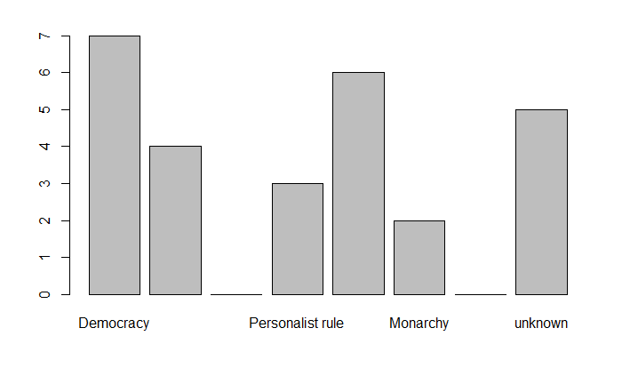

```r
barplot(table(test$Regime_type))
```

```r
NA
NA
```

Now a classification tree model will be created with rpart to predict whether or not a country is an ally using, the regime that country is classified as, the level of private ownership of banks in that country, and the level of government consumption in that country. Those variables will be chosen because PCA revealed that ownership of banks loads the highest onto the main principle component that describes the data, and government consumption loads the highest onto the second most important principle component for describing variation in the data.

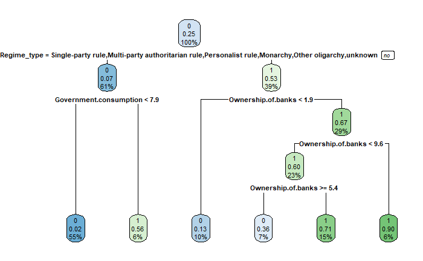

```r
library("rpart")
library("rpart.plot")
smart_tree <- rpart(alliance~Regime_type+Ownership.of.banks+Government.consumption,data = train, method ="class")
rpart.plot(smart_tree)
```

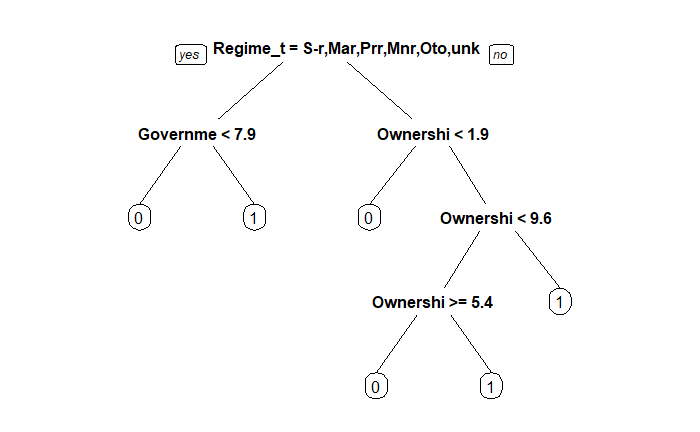

```r
prp(smart_tree)
```

The above tree shows clear evidence of over-fitting. The tree is classifying countries with ownership of banks higher than 1.9 as allies, except for those with ownership of banks between 5.4 and 9.6. This is very unlikely to be anything other than noise, so the max depth of the tree will be lowered to 3.

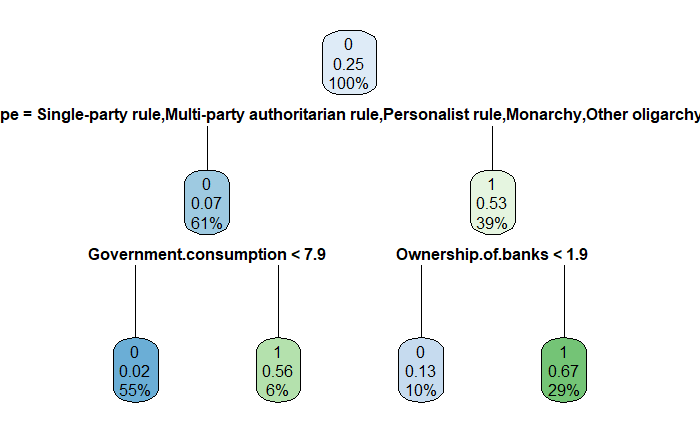

```r
smart_tree <- rpart(alliance~Regime_type+Ownership.of.banks+Government.consumption,data = train, method ="class",control = list(maxdepth = 3))
rpart.plot(smart_tree)
```

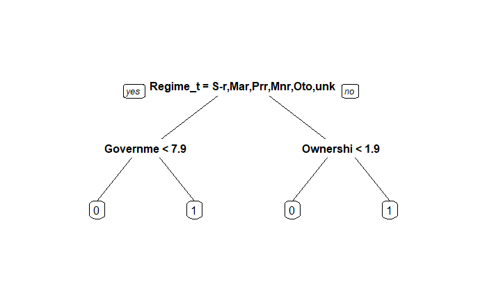

```r
prp(smart_tree)
```

The above tree is easy to interpret. If a regime falls into single-party rule, multi-party authoritarian rule, personalist rule, Monarchy, or other oligarchy, the US is not inclined to make an alliance with them unless government consumption is greater than 7.9. Since government consumption is reverse coded that corresponds to lower government consumption. For countries considered Democracies, or “military rule” provided ownership of banks is higher than 1.9 then the US is predicted to make an alliance with them.

Next models can be created that simply use the political variables or the economic variables for comparison sake.

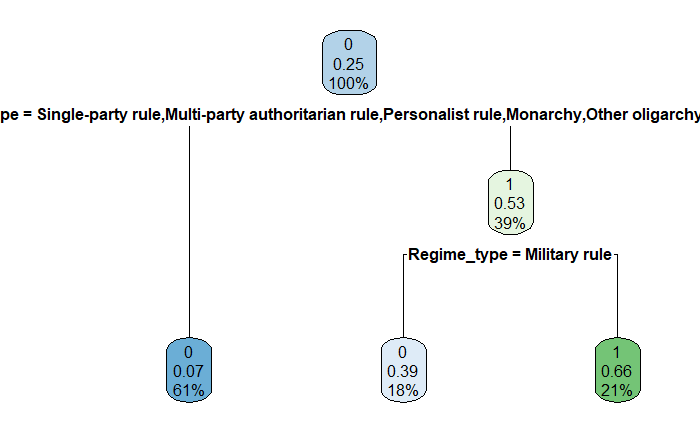

```r
poli_tree <- rpart(alliance~Regime_type,data = train, method ="class")
rpart.plot(poli_tree)
```

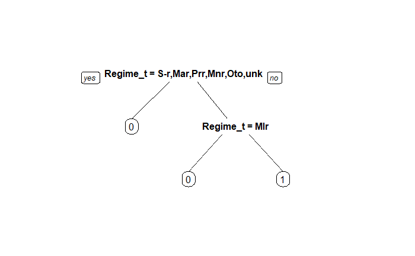

```r
prp(poli_tree)
```

```r
NA
NA
```

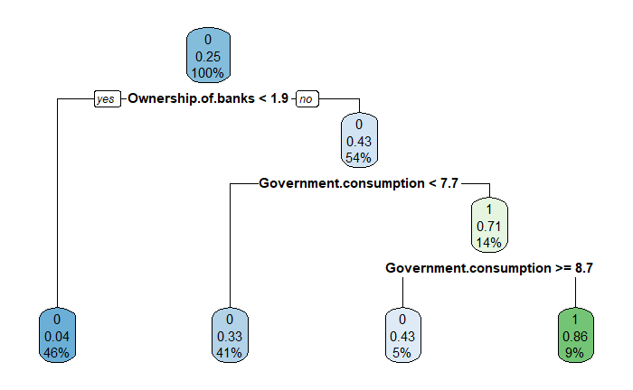

```r
econ_tree <- rpart(alliance~Ownership.of.banks+Government.consumption,data = train, method ="class",control = list(maxdepth = 3))
rpart.plot(econ_tree)
```

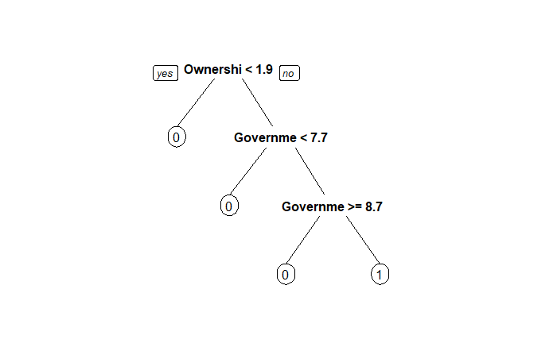

```r
prp(econ_tree)
```

With the tree depth of 3 the results are consistent with over-fitting so it should be reduced to 2

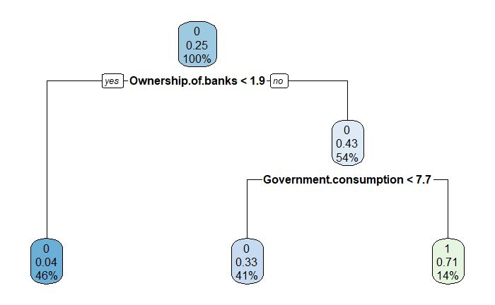

```r
econ_tree <- rpart(alliance~Ownership.of.banks+Government.consumption,data = train, method ="class",control = list(maxdepth = 2))
rpart.plot(econ_tree)
```

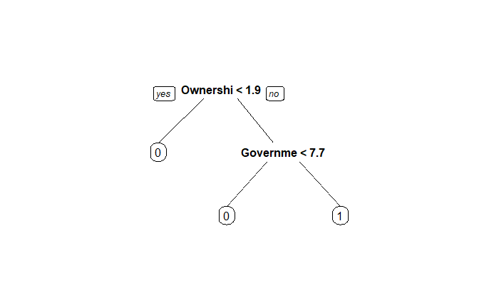

```r
prp(econ_tree)
```

```r
NA
NA
NA
```

The performance of all three models can be tested on the training and test data. First we can see a summary of the smart_tree

```r
summary(smart_tree)
```

```
Call:
rpart(formula = alliance ~ Regime_type + Ownership.of.banks +
    Government.consumption, data = train, method = "class", control = list(maxdepth = 3))
  n= 155

          CP nsplit rel error    xerror      xstd
1 0.19230769      0 1.0000000 1.0000000 0.1385259
2 0.02564103      2 0.6153846 0.7435897 0.1244955
3 0.01000000      3 0.5897436 0.8461538 0.1306792

Variable importance
           Regime_type     Ownership.of.banks Government.consumption
                    46                     35                     18

Node number 1: 155 observations,    complexity param=0.1923077
  predicted class=0  expected loss=0.2516129  P(node) =1
    class counts:   116    39
   probabilities: 0.748 0.252
  left son=2 (95 obs) right son=3 (60 obs)
  Primary splits:
      Regime_type            splits as  RLLLRLLL,     improve=15.539110, (0 missing)
      Ownership.of.banks     < 1.907662 to the left,  improve=11.484860, (0 missing)
      Government.consumption < 7.435    to the left,  improve= 9.248003, (0 missing)
  Surrogate splits:
      Ownership.of.banks     < 4.218433 to the left,  agree=0.748, adj=0.35, (0 split)
      Government.consumption < 7.386863 to the left,  agree=0.652, adj=0.10, (0 split)

Node number 2: 95 observations,    complexity param=0.02564103
  predicted class=0  expected loss=0.07368421  P(node) =0.6129032
    class counts:    88     7
   probabilities: 0.926 0.074
  left son=4 (86 obs) right son=5 (9 obs)
  Primary splits:
      Government.consumption < 7.91     to the left,  improve=4.617000, (0 missing)
      Regime_type            splits as  -LRR-LLL,     improve=1.253445, (0 missing)
      Ownership.of.banks     < 2.264192 to the left,  improve=1.058897, (0 missing)

Node number 3: 60 observations,    complexity param=0.1923077
  predicted class=1  expected loss=0.4666667  P(node) =0.3870968
    class counts:    28    32
```

[output cut: 11 more lines]

```

Node number 5: 9 observations
  predicted class=1  expected loss=0.4444444  P(node) =0.05806452
    class counts:     4     5
   probabilities: 0.444 0.556

Node number 6: 15 observations
  predicted class=0  expected loss=0.1333333  P(node) =0.09677419
    class counts:    13     2
   probabilities: 0.867 0.133

Node number 7: 45 observations
  predicted class=1  expected loss=0.3333333  P(node) =0.2903226
    class counts:    15    30
   probabilities: 0.333 0.667
```

```r
smart_tree_predictions = predict(smart_tree, data = train, type = "class")

table(train$alliance, smart_tree_predictions)
```

```
   smart_tree_predictions
     0  1
  0 97 19
  1  4 35
```

```r
econ_tree_predictions = predict(econ_tree, data = train,type = "class")

table(train$alliance, econ_tree_predictions)
```

```
   econ_tree_predictions
      0   1
  0 110   6
  1  24  15
```

```r
poli_tree_predictions = predict(poli_tree, data = train, type = "class")

table(train$alliance, poli_tree_predictions)
```

```
   poli_tree_predictions
      0   1
  0 105  11
  1  18  21
```

```r
smart_tree_predictions = predict(smart_tree, newdata = test, type = "class")

table(test$alliance, smart_tree_predictions)
```

```
   smart_tree_predictions
     0  1
  0 15  5
  1  2  5
```

```r
econ_tree_predictions = predict(econ_tree, newdata = test,type = "class")

table(test$alliance, econ_tree_predictions)
```

```
   econ_tree_predictions
     0  1
  0 16  4
  1  5  2
```

```r
poli_tree_predictions = predict(poli_tree, newdata = test, type = "class")

table(test$alliance, poli_tree_predictions)
```

```
   poli_tree_predictions
     0  1
  0 17  3
  1  3  4
```

```r
library('caret')
```

```
Error: package or namespace load failed for ‘caret’ in loadNamespace(j <- i[[1L]], c(lib.loc, .libPaths()), versionCheck = vI[[j]]):
 namespace ‘tibble’ 3.1.8 is already loaded, but >= 3.2.1 is required
```

```r
full_model<-glm(alliance~libdem_vdem_owid+Economic.Freedom.Summary.Index,
                family=binomial,data=train)

lib_model<-glm(alliance~libdem_vdem_owid,
                family=binomial,data=train)

cap_model<-glm(alliance~Economic.Freedom.Summary.Index,
                family=binomial,data=train)
```

```r
summary(full_model)
```

```
Call:
glm(formula = alliance ~ libdem_vdem_owid + Economic.Freedom.Summary.Index,
    family = binomial, data = train)

Deviance Residuals:
    Min       1Q   Median       3Q      Max
-1.8450  -0.6472  -0.4646   0.1574   2.3056

Coefficients:
                               Estimate Std. Error z value Pr(>|z|)
(Intercept)                     -7.1294     1.6548  -4.308 1.64e-05 ***
libdem_vdem_owid                 0.6773     1.1670   0.580  0.56167
Economic.Freedom.Summary.Index   1.0498     0.3196   3.285  0.00102 **
---
Signif. codes:  0 ‘***’ 0.001 ‘**’ 0.01 ‘*’ 0.05 ‘.’ 0.1 ‘ ’ 1

(Dispersion parameter for binomial family taken to be 1)

    Null deviance: 174.87  on 154  degrees of freedom
Residual deviance: 139.37  on 152  degrees of freedom
AIC: 145.37

Number of Fisher Scoring iterations: 4
```

```r
library(lmtest)

### Comparing the crude model (logit1) to the adjusted model (logit2)
lrtest(lib_model, cap_model)
```

```
Likelihood ratio test

Model 1: alliance ~ libdem_vdem_owid
Model 2: alliance ~ Economic.Freedom.Summary.Index
  #Df  LogLik Df  Chisq Pr(>Chisq)
1   2 -75.620
2   2 -69.852  0 11.537  < 2.2e-16 ***
---
Signif. codes:  0 ‘***’ 0.001 ‘**’ 0.01 ‘*’ 0.05 ‘.’ 0.1 ‘ ’ 1
```